# CRJ504 - Inference for Categorical Data

October 29, 2018

### Announcements

- November 12, 2018 class is cancelled. I can be available later that week to answer questions.
- Datasets for homework assignments have been updated. Located here: https://github.com/jbryer/CRJ504Fall2018/tree/master/data/os3_data

### Agenda

- Exercise 5.48
- Chapter 6 lecture
- Data Project Proposals
- Start Lab 5

## Exercise 5.48

```r
gss2010 <- read.csv('../data/os3_data/Ch 5 Exercise Data/gss2010.csv')
gss2010$degree <- factor(as.character(gss2010$degree),
                         levels = c('LT HIGH SCHOOL', 'HIGH SCHOOL', 'JUNIOR COLLEGE',
                                   'BACHELOR', 'GRADUATE'),
                         ordered = TRUE)
tab <- psych::describeBy(gss2010$hrs1, group = gss2010$degree, mat = TRUE)[,c('group1','mean','sd','n')]
tab
```

```
##             group1     mean       sd   n
## X11 LT HIGH SCHOOL 38.66942 15.81423 121
## X12    HIGH SCHOOL 39.59707 14.97125 546
## X13 JUNIOR COLLEGE 41.39175 18.10361  97
## X14       BACHELOR 42.54941 13.61731 253
## X15       GRADUATE 40.84516 15.50540 155
```

## Exercise 5.48 (cont.)

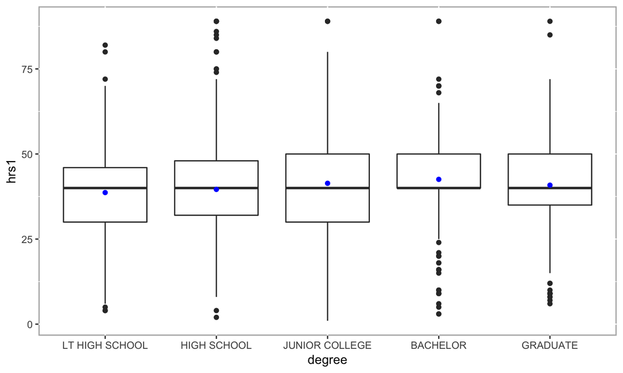

```r
ggplot(gss2010, aes(x = degree, y = hrs1)) + geom_boxplot() +
    geom_point(data = tab, aes(x = group1, y = mean), color = 'blue')
```

## Exercise 5.48 (cont.)

**a) Write hypotheses for evaluating whether the average number of hours worked varies across the five groups.**

\[ H_{0}: \mu_{LTHS} = \mu_{HS} = \mu_{JC} = \mu_{B} = \mu_{G} \]

## Exercise 5.48 (cont.)

**b) Check conditions and describe any assumptions you must make to proceed with the test.**

- Check for outliers within any group.
- Check for similar spreads.
- Look for skewness.
- Independence Assumption
  - Groups must be independent of each other.
  - Data within each group must be independent.
  - Randomization Condition
- Equal Variance Assumption

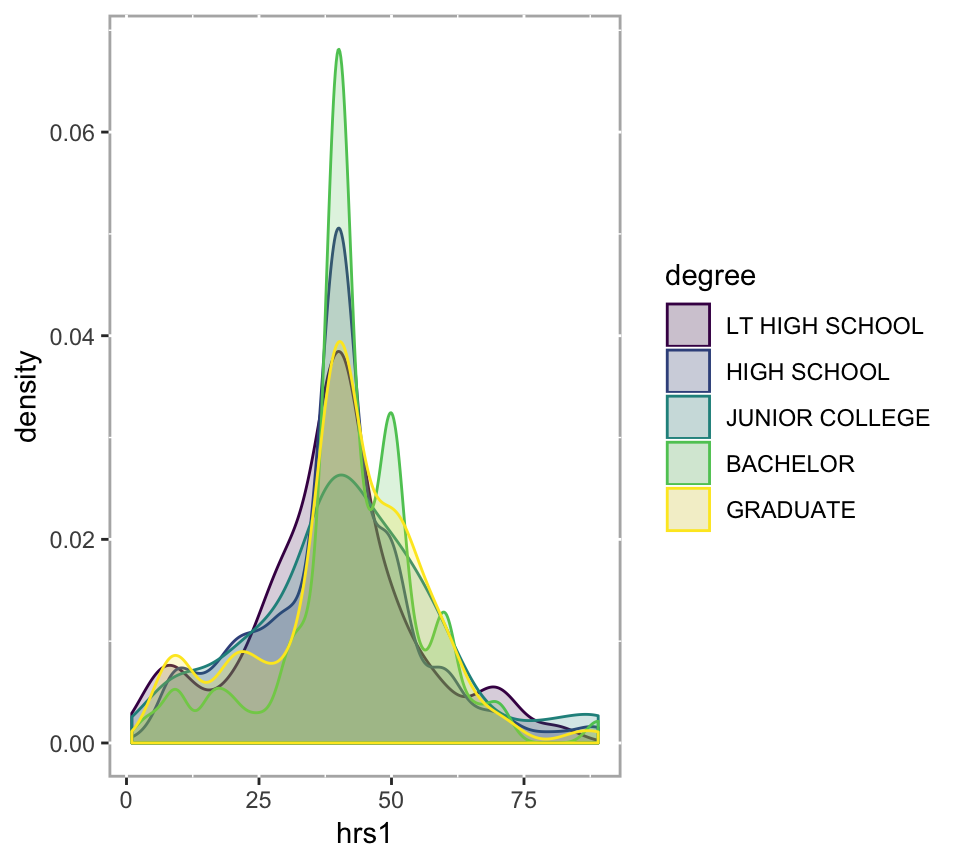

```r
ggplot(gss2010, aes(x=hrs1, fill=degree,
                    color=degree)) +
    geom_density(alpha = 0.2)
```

## Exercise 5.48 (cont.)

**c) Below is part of the output associated with this test. Fill in the empty cells.**

```r
summary(aov(hrs1 ~ degree, data = gss2010))
```

```
##               Df Sum Sq Mean Sq F value Pr(>F)
## degree         4   2006   501.5   2.189 0.0682 .
## Residuals   1167 267382   229.1
## ---
## Signif. codes:  0 '***' 0.001 '**' 0.01 '*' 0.05 '.' 0.1 ' ' 1
## 872 observations deleted due to missingness
```

**D) What is the conclusion of the test?**

We would fail to reject the null hypothesis.

## Example

Two scientists want to know if a certain drug is effective against high blood pressure. The first scientist wants to give the drug to 1,000 people with high blood pressure and see how many of them experience lower blood pressure levels. The second scientist wants to give the drug to 500 people with high blood pressure, and not give the drug to another 500 people with high blood pressure, and see how many in both groups experience lower blood pressure levels. Which is the better way to test this drug?

- **500 get the drug, 500 don’t**

## Survey of Americans

The GSS asks the same question, below is the distribution of responses from the 2010 survey:

| Response | n |
| --- | --- |
| All 1000 get the drug | 99 |
| 500 get the drug 500 don’t | 571 |
| **Total** | **670** |

## Parameter of Interest

- Parameter of interest: Proportion of *all* Americans who have good intuition about experimental design.  
  \[p(population\; proportion)\]
- Point estimate: Proportion of *sampled* Americans who have good intuition about experimental design.  
  \[\hat{p}(sample\; proportion)\]

## Inference for a proportion

What percent of all Americans have good intuition about experimental design, i.e. would answer “500 get the drug 500 don't?"

- Using a confidence interval \[point\; estimate \pm ME\]
- We know that ME = critical value x standard error of the point estimate. \[SE_{\hat{p}} = \sqrt{\frac{p(1-p)}{n}}\]

## Central limit theoreom for proportions

Sample proportions will be nearly normally distributed with mean equal to the population mean, *p*, and standard error equal to \(\sqrt{\frac{p(1-p)}{n}}\).

\[\hat { p } \sim N\left( mean=p,SE=\sqrt { \frac { p(1-p) }{ n } } \right) \]

This is true given the following conditions:

- independent observations
- at least 10 successes and 10 failures

## Back to the Survey

- 571 out of 670 (85%) of Americans answered the question on experimental design correctly.
- Estimate (using a 95% confidence interval) the proportion of all Americans who have good intuition about experimental design?

Given: \(n = 670\), \(\hat{p} = 0.85\).

Conditions:

1. Independence: The sample is random, and 670 < 10% of all Americans, therefore we can assume that one respondent’s response is independent of another.
2. Success-failure: 571 people answered correctly (successes) and 99 answered incorrectly (failures), both are greater than 10.

## Calculating Confidence Interval

Given: \(n = 670\), \(\hat{p} = 0.85\).

\[0.85 \pm 1.96 \sqrt{\frac{0.85 \times 0.15}{670}} = \left(0.82,\; 0.88\right)\]

We are 95% confidence the true proportion of Americans that have a good intuition about experimental designs is betwee 82% and 88%.

## How many should we sample?

Suppose you want a 3% margin of error, how many people would you have to survey?

Use \(\hat{p} = 0.5\)

- If you don’t know any better, 50-50 is a good guess
- \(\hat{p} = 0.5\) gives the most conservative estimate – highest possible sample size

\[0.03 = 1.96 \times \sqrt{\frac{0.5 \times 0.5}{n}}\] \[0.03^2 = 1.96^2 \times \frac{0.5 \times 0.5}{n}\] \[n \approx 1,068\]

## Example: Two Proportions

Scientists predict that global warming may have big effects on the polar regions within the next 100 years. One of the possible effects is that the northern ice cap may completely melt. Would this bother you a great deal, some, a little, or not at all if it actually happened?

[output not shown]

## Parameter and Point Estimate

Parameter of interest: Difference between the proportions of *all* Duke students and *all* Americans who would be bothered a great deal by the northern ice cap completely melting.

\[p_{Duke} - p_{US}\]

Point estimate: Difference between the proportions of *sampled* Duke students and *sampled* Americans who would be bothered a great deal by the northern ice cap completely melting.

\[\hat{p}_{Duke} - \hat{p}_{US}\]

## Everything else is the same…

- CI: \(point\; estimate \pm margin\; of\; error\)
- HT: \(Z = \frac{point\; estimate - null\; value}{SE}\)

Standard error of the difference between two sample proportions

\[SE_{\hat{p}_1 - \hat{p}_2} = \sqrt{ \frac{p_1\left(1 - p_1\right)}{n_1} + \frac{p_2\left(1 - p_2\right)}{n_2} }\]

Conditions:

1. Independence within groups: The US group is sampled randomly and we’re assuming that the Duke group represents a random sample as well. \(n_{Duke} < 10\%\) of all Duke students and \(680 < 10\%\) of all Americans.
2. Independence between groups: The sampled Duke students and the US residents are independent of each other.
3. Success-failure: At least 10 observed successes and 10 observed failures in the two groups.

Construct a 95% confidence interval for the difference between the proportions of Duke students and Americans who would be bothered a great deal by the melting of the northern ice cap (\(p_{Duke} − p_{US}\)).

| Data | Duke | US |
| --- | --- | --- |
| A great deal | 69 | 454 |
| Not a great deal | 36 | 226 |
| Total | 105 | 680 |
| \(\hat{p}\) | 0.657 | 0.668 |

\[ \left(\hat{p}_{Duke} - \hat{p}_{US}\right) \pm z* \times \sqrt{ \frac{p_{Duke}\left(1 - p_{Duke}\right)}{n_{Duke}} + \frac{p_{US}\left(1 - p_{US}\right)}{n_{US}} } \]

\[(0.657 − 0.668) \pm 1.96 \times \sqrt{\frac{0.657 \times 0.343}{105} + \frac{0.668 \times 0.332}{680}} = \left(-0.108,\; 0.086\right)\]